# Assignment 5

Will Doyle

11/30/2021

```r
library(tidyverse)
library(tidymodels)
ad<-read_rds("admit_data.rds")
```

Complete the following steps:

1. Plot yield as a function of income

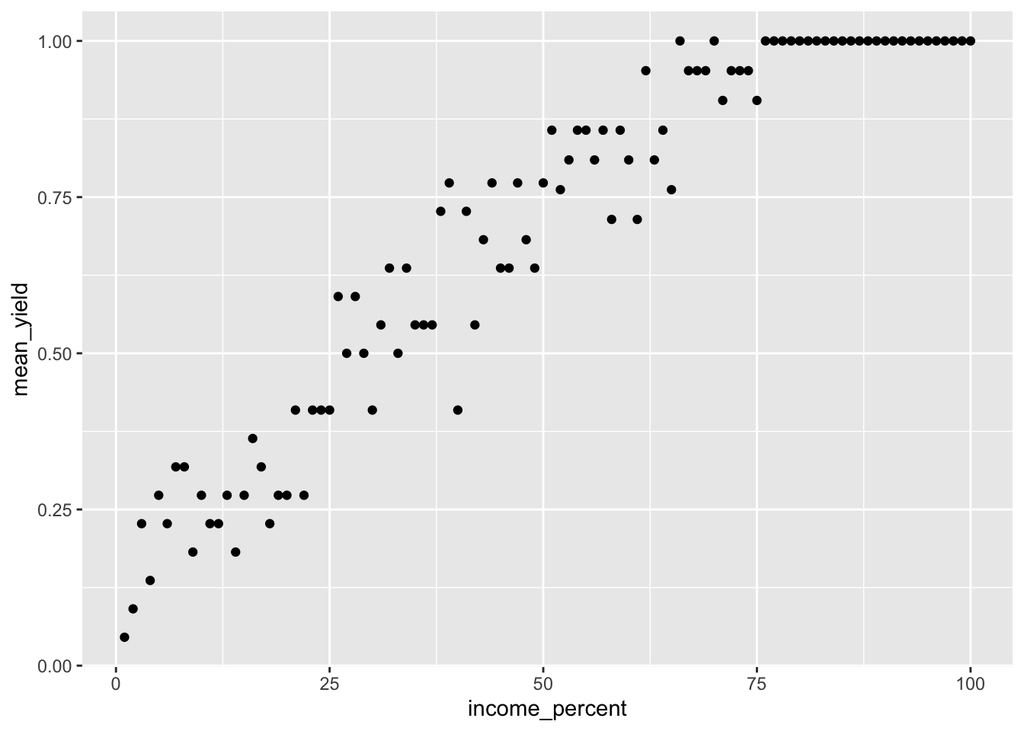

```r
ad%>%
  mutate(income_percent=ntile(income,n=100))%>%
  group_by(income_percent)%>%
  summarize(mean_yield=mean(yield))%>%
  ggplot(aes(x=income_percent,y=mean_yield))+
  geom_point()
```

1. Calculate the proportion who yielded as a function of income decile and comment briefly on the results.

```r
ad%>%
  mutate(income_percent=ntile(income,n=10))%>%
  group_by(income_percent)%>%
  summarize(mean_yield=mean(yield))
```

```
## # A tibble: 10 × 2
##    income_percent mean_yield
##             <int>      <dbl>
##  1              1      0.205
##  2              2      0.265
##  3              3      0.447
##  4              4      0.591
##  5              5      0.651
##  6              6      0.809
##  7              7      0.884
##  8              8      0.967
##  9              9      1
## 10             10      1
```

Higher income students are much more likely to yield than low income students– only 20 percent of low income students attend, while all high income students attend.

2. Run a regression with yield as a function of income and sent scores. Comment on the coefficients.

```r
ad_split<-initial_split(ad)

ad_train<-training(ad_split)

ad_test<-testing(ad_split)
```

```r
lm_fit<-linear_reg()%>%
  set_engine("lm")%>%
  set_mode("regression")
```

```r
yield_formula<-as.formula("yield~income+sent_scores")

yield_recipe<-recipe(yield_formula,ad_train)
```

```r
yield_wf<-workflow()%>%
  add_model(lm_fit)%>%
  add_recipe(yield_recipe)
```

```r
yield_wf<-yield_wf%>%
  fit(ad_train)
```

```r
yield_wf%>%tidy()
```

```
## # A tibble: 3 × 5
##   term          estimate   std.error statistic   p.value
##   <chr>            <dbl>       <dbl>     <dbl>     <dbl>
## 1 (Intercept) 0.403      0.0171          23.6  6.43e-106
## 2 income      0.00000204 0.000000104     19.7  8.96e- 78
## 3 sent_scores 0.0919     0.0260           3.53 4.29e-  4
```

3. Run a logistic regression with yield as a function of income and sent scores. Again comment on the coefficients.

```r
ad<-ad%>%
  mutate(yield_f=ifelse(yield==1,"Yes","No"))%>%
  mutate(yield_f=fct_relevel(yield_f,ref="No"))
```

```r
ad_split<-initial_split(ad)

ad_train<-training(ad_split)

ad_test<-testing(ad_split)
```

```r
yield_formula<-as.formula("yield_f~income+sent_scores")

yield_recipe<-recipe(yield_formula,ad_train)
```

```r
logit_mod<-logistic_reg()%>%
  set_engine("glm")%>%
  set_mode("classification")
```

```r
yield_wf<-workflow()%>%
  add_model(logit_mod)%>%
  add_recipe(yield_recipe)
```

```r
yield_wf<-yield_wf%>%
  fit(ad_train)
yield_wf%>%tidy()
```

```
## # A tibble: 3 × 5
##   term          estimate  std.error statistic  p.value
##   <chr>            <dbl>      <dbl>     <dbl>    <dbl>
## 1 (Intercept) -2.82      0.183         -15.4  1.48e-53
## 2 income       0.0000379 0.00000218     17.4  5.02e-68
## 3 sent_scores  0.719     0.191           3.77 1.60e- 4
```

Income has a positive and statistically significant relationship with yield, as does sent scores.

4. Calculate the accuracy, specificity and sensitivity of the predictions from your logistic regression above. Comment briefly on each.

```r
##  Check baseline first

ad%>%
  summarize(mean(yield))
```

```
##   mean(yield)
## 1   0.6818605
```

```r
yield_wf%>%
  predict(ad_test)%>%
  bind_cols(ad_test)%>%
  accuracy(truth=yield_f,estimate=.pred_class,event_level="second")
```

```
## # A tibble: 1 × 3
##   .metric  .estimator .estimate
##   <chr>    <chr>          <dbl>
## 1 accuracy binary         0.803
```

```r
yield_wf%>%
  predict(ad_test)%>%
  bind_cols(ad_test)%>%
  sens(truth=yield_f,estimate=.pred_class,event_level="second")
```

```
## # A tibble: 1 × 3
##   .metric .estimator .estimate
##   <chr>   <chr>          <dbl>
## 1 sens    binary         0.870
```

```r
yield_wf%>%
  predict(ad_test)%>%
  bind_cols(ad_test)%>%
  spec(truth=yield_f,estimate=.pred_class,event_level="second")
```

```
## # A tibble: 1 × 3
##   .metric .estimator .estimate
##   <chr>   <chr>          <dbl>
## 1 spec    binary         0.632
```

5. Calculate the AUC from the logistic regression and state whether you have achieved good model fit.

```r
yield_wf%>%
  predict(ad_test,type="prob")%>%
  bind_cols(ad_test)%>%
  roc_auc(truth=yield_f,estimate=.pred_Yes,event_level="second")
```

```
## # A tibble: 1 × 3
##   .metric .estimator .estimate
##   <chr>   <chr>          <dbl>
## 1 roc_auc binary         0.866
```

The AUC for the model is .86, indicating a reasonable degree of both sensitivity and specificity at a variety of different thresholds.